# In Class Activity - Plotting

Author

Rodney

Abstract

This is an in-class activity. I have given prompts to create a variety of graph types using the Rice Rivers Center data.

**Important**

When you make a Markdown document that creates graphics, you want to make sure that you have set `self-contained: true` in the top YAML. This embeds the images into the resulting single HTML file instead of making them adjacent to the HTML file. This will **ensure** your document has the graphical output when you turn it in without needing to upload a zip archive.

## The Data

Let’s start by playing around with some of the [Rice Rivers Center](https://ricerivers.vcu.edu) data. Make sure that the file `get_rice_data.R` is in the same folder (and the folder of your course Project).

The code in the next chunk will load in, and format, the Rice Data for us.

```r
library( tidyverse )
# grab the code from inside that file
source( "get_rice_data.R" )

# use the function
get_rice_data() -> rice

# take a look at it
summary( rice )
```

```
      Date                          Month           Day            Weekday
 Min.   :2014-01-01 00:00:00   January :2976   Min.   : 1.0   Sunday   :1152
 1st Qu.:2014-01-22 08:22:30   February:2688   1st Qu.: 8.0   Monday   :1152
 Median :2014-02-12 16:45:00   March   :2535   Median :15.0   Tuesday  :1152
 Mean   :2014-02-12 16:45:00                   Mean   :14.8   Wednesday:1248
 3rd Qu.:2014-03-06 01:07:30                   3rd Qu.:22.0   Thursday :1191
 Max.   :2014-03-27 09:30:00                   Max.   :31.0   Friday   :1152
                                                              Saturday :1152
 Air_Temperature         Rain           Wind_Speed     Wind_Direction
 Min.   :-15.6950   Min.   :0.00000   Min.   : 0.000   Min.   :  0.00
 1st Qu.: -0.2528   1st Qu.:0.00000   1st Qu.: 3.947   1st Qu.: 37.31
 Median :  3.0222   Median :0.00000   Median : 6.544   Median :137.30
 Mean   :  3.7751   Mean   :0.02137   Mean   : 8.713   Mean   :146.20
 3rd Qu.:  8.0056   3rd Qu.:0.00000   3rd Qu.:11.666   3rd Qu.:249.95
 Max.   : 23.8167   Max.   :8.81380   Max.   :49.040   Max.   :360.00

    Humidity     Barametric_Pressure      PAR           Water_Temperature
 Min.   :15.37   Min.   :29.11       Min.   :   0.000   Min.   :-0.140
 1st Qu.:42.25   1st Qu.:29.87       1st Qu.:   0.000   1st Qu.: 3.930
 Median :56.40   Median :30.01       Median :   0.046   Median : 5.450
 Mean   :58.37   Mean   :30.02       Mean   : 241.984   Mean   : 5.529
 3rd Qu.:76.59   3rd Qu.:30.21       3rd Qu.: 337.900   3rd Qu.: 7.410
 Max.   :93.00   Max.   :30.58       Max.   :1957.000   Max.   :13.300
                                                        NA's   :1
  Water_Depth       Salinity            pH         Turbidity
 Min.   :3.705   Min.   :0.0000   Min.   :6.43   Min.   :  6.20
 1st Qu.:4.451   1st Qu.:0.0700   1st Qu.:7.50   1st Qu.: 15.50
 Median :4.684   Median :0.0800   Median :7.58   Median : 21.80
 Mean   :4.677   Mean   :0.0759   Mean   :7.60   Mean   : 24.54
 3rd Qu.:4.913   3rd Qu.:0.0800   3rd Qu.:7.69   3rd Qu.: 30.30
 Max.   :5.454   Max.   :0.1000   Max.   :9.00   Max.   :187.70
                 NA's   :1        NA's   :1      NA's   :1
   Chlorophyl         ODO
 Min.   :  1.3   Min.   : 87.5
 1st Qu.:  3.7   1st Qu.: 99.2
 Median :  6.7   Median :101.8
 Mean   :137.3   Mean   :102.0
 3rd Qu.:302.6   3rd Qu.:104.1
 Max.   :330.1   Max.   :120.8
 NA's   :1       NA's   :1
```

## Classic Graphics

The following basic graphs focus on the built-in `classic` plotting techniques.

*Univariate - Histograms*

Create a histogram of water temperature (displayed in Figure 1). Make the bars a nice shade of blue and create the labels on the axes that properly describe the data.

I have added metadata to this chunck to show you how to make labels and captions so you can reference the figure in the text. Do this for **all** the remaining plots in this activity.

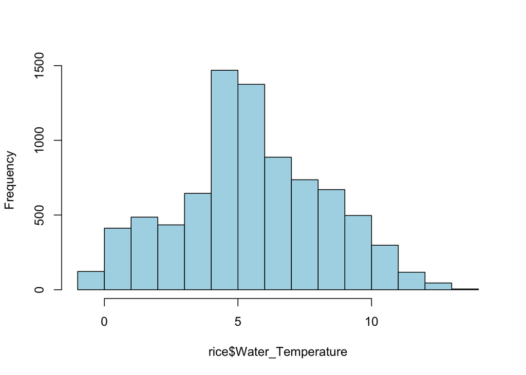

Figure 1: The distribution of water temperature measured at the Rice Rivers Center over the first months of 2014.

```r
hist( rice$Water_Temperature,
      main="",
      col="lightblue" )
```

*Density Plots*

For the same data, create a *probability density plot* using the `density()` function.

### Bivariate

*Scatter Plots*

Filter the Rice Center data for samples during New Years Day in 2014. Create a scatter plot of Wind Speed and Barametric Pressure, properly annotated and referenced in the text.

*Customization*

Here are some methods for customization of components in a classic graph.

[output not shown]

Use the scatter plot above and customize the color and shape of the plots. Annotate properly.

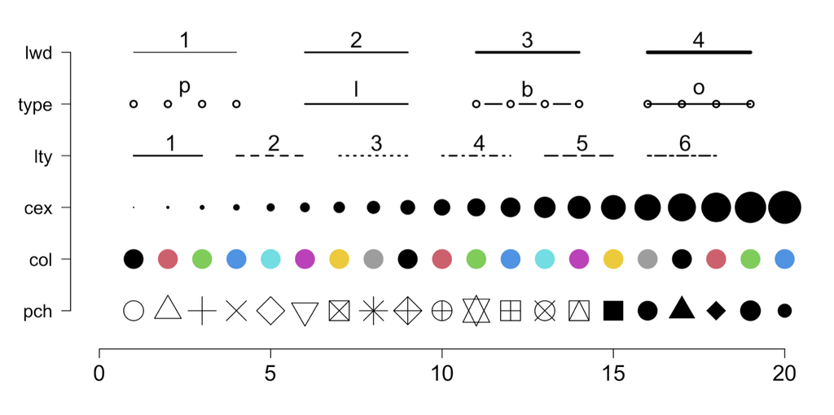

*Color spaces*

Here are some external components related to colors and plotting:

- Hex ([coolors](https://coolors.co/))
- Named (via `colors()`)
- [ColorBrewer](https://colorbrewer2.org/)

Color brewer is a great resources you can use as necessary.

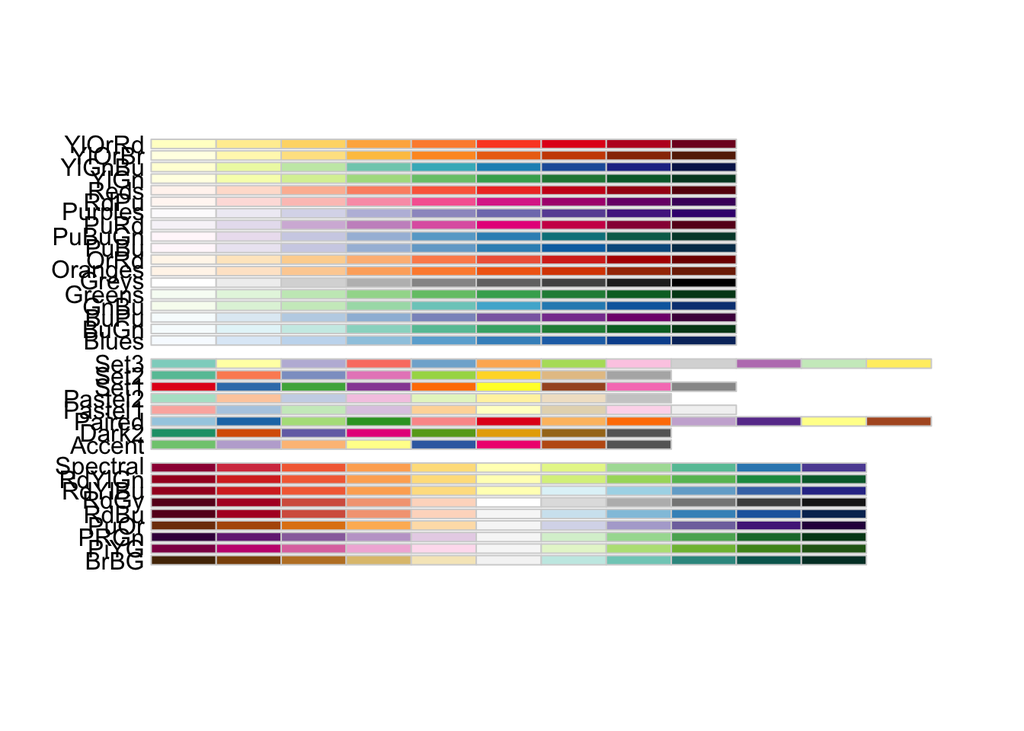

```r
library(RColorBrewer)
display.brewer.all()
```

*Boxplots*

Filter the Rice Center Data for samples in February. Create a box plot by day of the week showing differences in Water Temperature. Label the graph properly and create links and captions. Write one or two sentences describing what this graph is telling us.

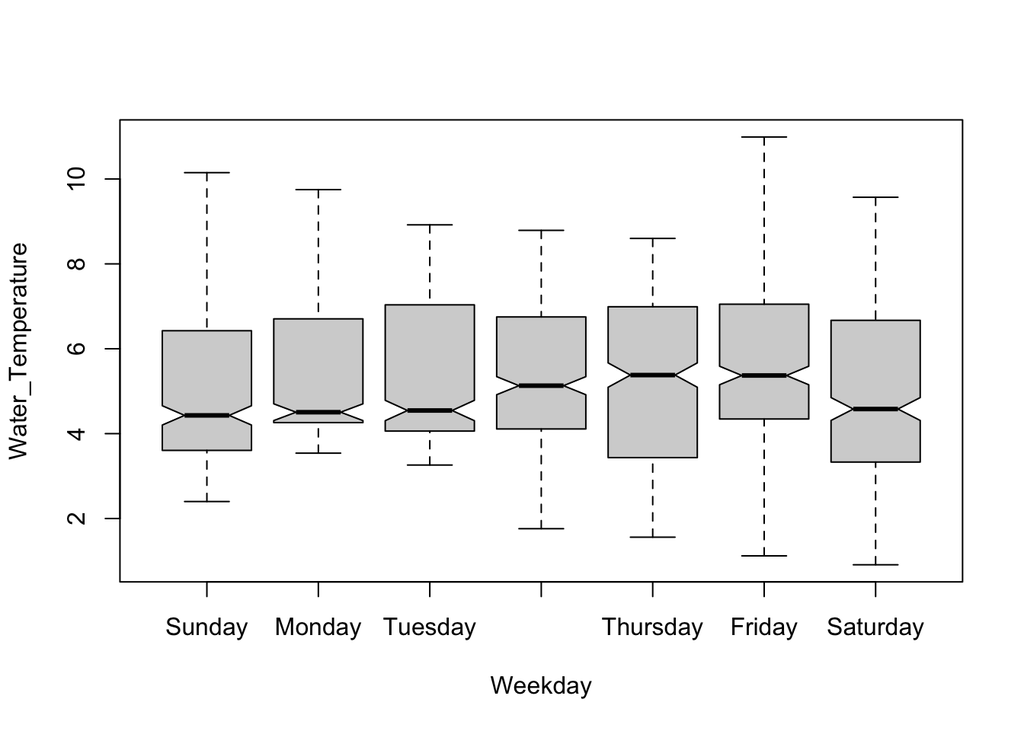

```r
rice |>
  filter( Month == "February" ) -> rce
boxplot( Water_Temperature ~ Weekday, data = rce, notch = TRUE)
```

*Text Overlays*

Use the data from your scatter plot above. Use the function `cor()` to determine the correlation between the parameters `Wind_Speed` and `Barametric_Pressure`. Use `text()` to overlay the correlation on the graph.

## GGPlot Graphics

### Univariate Data

*Histograms*

Create the same histogram as you did above.

*Barplots*

### Bivariate Data

*Scatter Plots*

Create the same scatter plot with text overlay of the correlation as you did above. Explore themes if you like.